# HW1

Jeffrey Liang, zl2974

*Code available at https://github.com/zl2974/P8130_hw1_zl2974/*

# Problem 1

## Descriptive statistics to the data

The data is a 1491 $\cdot$ 5 shape data with 1491 objects. There’re 1224 missing values in the data. After cleaning missing values as well as the ‘Unansered/Others’ report from *Smell* variable, 259 objects remain. Descriptive statistics of the original dataset was provided below, 1224 value missing occurred at Antibody level’s columns. Also provided with catagorical data’s count table, no missing value in catagorcial data.

Data summary

| Name | smell_df |
| --- | --- |
| Number of rows | 1491 |
| Number of columns | 5 |
| _______________________ |  |
| Column type frequency: |  |
| factor | 3 |
| numeric | 2 |
| ________________________ |  |
| Group variables | None |

**Variable type: factor**

| skim_variable | n_missing | complete_rate | ordered | n_unique | top_counts |
| --- | --- | --- | --- | --- | --- |
| smell | 0 | 1 | FALSE | 3 | Alt: 1047, Nor: 410, Una: 34 |
| gender | 0 | 1 | FALSE | 2 | Fem: 981, Mal: 510 |
| age_category | 0 | 1 | FALSE | 3 | 31-: 810, 51+: 363, 18-: 318 |

**Variable type: numeric**

| skim_variable | n_missing | complete_rate | mean | sd | p0 | p25 | p50 | p75 | p100 |
| --- | --- | --- | --- | --- | --- | --- | --- | --- | --- |
| subject | 0 | 1.00 | 1413.75 | 881.07 | 1.00 | 632.50 | 1373.00 | 2190.50 | 2917.00 |
| antibody_ig_m | 1224 | 0.18 | 0.12 | 0.11 | 0.05 | 0.07 | 0.09 | 0.13 | 1.05 |

```
##
## Table: Catagorical Variable Statistics
##
## |                     | Overall (N=1491) |
## |:--------------------|:----------------:|
## |age_category         |                  |
## |-  18-30             |   318 (21.3%)    |
## |-  31-50             |   810 (54.3%)    |
## |-  51+               |   363 (24.3%)    |
## |-  Missing           |        0         |
## |smell                |                  |
## |-  Normal            |   410 (27.5%)    |
## |-  Altered           |   1047 (70.2%)   |
## |-  Unanswered/Others |    34 (2.3%)     |
## |-  Missing           |        0         |
## |gender               |                  |
## |-  Female            |   981 (65.8%)    |
## |-  Male              |   510 (34.2%)    |
## |-  Missing           |        0         |
```

## Distribution of IgM

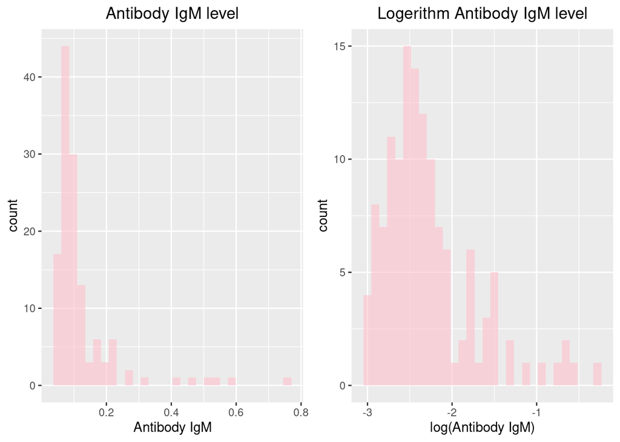

## Smell *Alter* and *Normal* Comparison

Grouped subjects with altered smell and normal, we have seen that subjects from group smell altered have higher antibody level compared with normal group. Also, spread of Altered group’s antibody level is wider than the spread of normal smell group judging from both range and standard deviation.

```
##
## Table: Smell
##
## |                   |    Normal (N=81)     |   Altered (N=178)    |
## |:------------------|:--------------------:|:--------------------:|
## |antibody_ig_m      |                      |                      |
## |-  Mean (SD)       |    0.110 (0.092)     |    0.130 (0.119)     |
## |-  Median (Q1, Q3) | 0.081 (0.065, 0.107) | 0.097 (0.072, 0.137) |
## |-  Min - Max       |    0.049 - 0.589     |    0.048 - 1.048     |
## |gender             |                      |                      |
## |-  Female          |      47 (58.0%)      |     120 (67.4%)      |
## |-  Male            |      34 (42.0%)      |      58 (32.6%)      |
## |age_category       |                      |                      |
## |-  18-30           |      13 (16.0%)      |      36 (20.2%)      |
## |-  31-50           |      43 (53.1%)      |     101 (56.7%)      |
## |-  51+             |      25 (30.9%)      |      41 (23.0%)      |
```

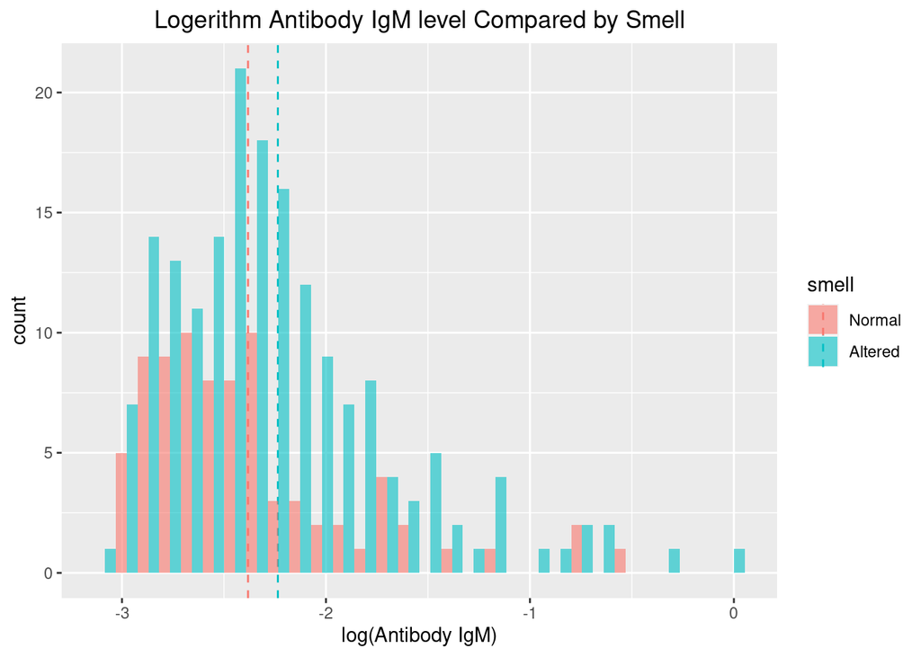

# Problem 2

*I’ve chosen* *More Testing Needed: Most Coronavirus Cases Come From People Unaware They’re Infected* *as my interest for problem 2’s article.*

In the news of choice<sup>1</sup>, the author introduced result from the article from Li,R et.al<sup>2</sup>. The author introduce the result of the paper via transcript and direct quotes for her article. For example, the article quoted *“Our findings also indicate that a radical increase in the identification and isolation of currently undocumented infections would be needed to fully control SARS-CoV2,”* directly to support her claim of *‘Without enough testing to rapidly identify everyone who has the disease and separate them from others, the disease will continue to spread quickly.’*

In other news reports, Columbia’s news use directed quotes to the paper<sup>3</sup>. In ScienceDaily, the report first summary the paper and following use transcript as well as quotes to introduce the contents of the paper.

There’s a few relative news reports also referring to the same published article.

And here’s **some** claims made in the article based on the Li,R’s findings and are listed as followed:

- The ability of a respiratory disease to become a pandemic depends in part on how many infectious people are not aware that they’re infectious
- That means if someone were able to completely isolate themselves immediately after they were exposed to the virus, it would tremendously cut down the total infection rate. Each person would only infect about one other person.
- Without enough testing to rapidly identify everyone who has the disease and separate them from others, the disease will continue to spread quickly.
- COVID-19 will be like H1N1 becoming a global endemic

The ScienceDaily report agree on bullet point 1 and 3, regarding asymtomatic and COVID-19 becoming a pandemic.

To validate these points in the report, we must first dig into the reference paper and make comparison on the claims in report and in the paper.

## *Substantial undocumented infection facilitates the rapid dissemination of novel coronavirus (SARS-CoV-2)*

Li, R’s paper tried to calculate the proportion of undocumented COVID-19 cases and their transmission. To unravel characteristic of undocumented COVID-19, the author conducted an observational study with reported infection case and mobility data from tech company and applied bayesian inference model to interpret proportion of undocumented cases during 25 days before 10th, Jan. and 15 day after. And the paper found result:

- Basic reproductive number R<sub>0</sub> 2.38(CI:2.03-2.77) during 10-23 Januray and only 14% total infections were reported (in another word: 86% of undocumented infections);
- These undocumented infections had halved transmission compared to reported cases;
- After implement of control measures(social-distancing and etc.), transmission rate of documented cases, $\beta$, dropped to 0.52 (CI:0.42–0.72) to 0.35 (0.28–0.45) as well as the R<sub>0</sub> (to 1.34(CI:1.10-1.67));
- Proportion of undocumented cases has dropped to 35%.
- fully identify undocumented disease is need to fully control COVID-19.
- COVID-19 can become the 5<sup>th</sup> global endemic

## Summary

Comparing the news and paper, one have to admit that the Forbe’s news has done good job putting the facts from the paper. All claims can be found from the *Introduction*, *Result* and *Conclusion* from the paper. But minor drawback of the news report is the definition of asymptomatic patients is not matching the define of undocumented infections of Li’s paper. Asymptomatic patients are include in the undocumented infections, which stating the asymptomatic shares the characteristics of undocumented infections would over-estimated it.

## Reference

1. *More Testing Needed: Most Coronavirus Cases Come From People Unaware They’re Infected:* https://www.forbes.com/sites/tarahaelle/2020/03/20/more-testing-needed-most-coronavirus-cases-come-from-people-unaware-theyre-infected/#3ccf8ddc2988
2. *Substantial undocumented infection facilitates the rapid dissemination of novel coronavirus (SARS-CoV-2)*: https://science.sciencemag.org/content/sci/368/6490/489.full.pdf
3. *‘Stealth Transmission’ Fuels Fast Spread of Coronavirus Outbreak:* https://www.publichealth.columbia.edu/public-health-now/news/stealth-transmission-fuels-fast-spread-coronavirus-outbreak
4. *‘Stealth transmission’ fuels fast spread of coronavirus outbreak:* https://www.sciencedaily.com/releases/2020/03/200316141454.htm